# Estudo de Home Page

```r
base <- read.csv('C:/Users/lucas.general/Documents/Documentos R Markdown/Comportamento/Home/Home_Page.CSV', encoding = "UTF-8")

g_legend<-function(a.gplot){
  tmp <- ggplot_gtable(ggplot_build(a.gplot))
  leg <- which(sapply(tmp$grobs, function(x) x$name) == "guide-box")
  legend <- tmp$grobs[[leg]]
  return(legend)}


base <- base %>% mutate(pedidos2 = ifelse(pedidos == 0, 'Sem Pedido',
                                          ifelse(pedidos == 1, '1 Pedido',
                                                 ifelse(pedidos == 2, '2 Pedidos',
                                                        '3 ou mais pedidos'))))

base <- base %>%
  inner_join(
    base %>%
      select(pk_customer, infantil, masculino, feminino, casa) %>%
      mutate(infantil = ifelse(infantil > 0,1,0),
             masculino = ifelse(masculino > 0,1,0),
             feminino = ifelse(feminino > 0,1,0),
             casa = ifelse(casa > 0,1,0),
             diferentes_homes = infantil+masculino+feminino+casa) %>%
      select(pk_customer,diferentes_homes),
    by = 'pk_customer')


base <- base %>%
  mutate(pedidos2 = factor(pedidos2, levels = c('Sem Pedido', '1 Pedido', '2 Pedidos', '3 ou mais pedidos')))
```

Acompanhamos todas as interações dos clientes que tiveram primeira visita entre 2020-01 e 2020-02 por 1 ano. Os resultados a seguir são todas as interações que estes clientes tiveram neste período.

A análise está quebrada em 4 estágios:

- Perfil dos clientes que acessam a Home
- Quando foi essa Home
- Frequencia de acesso a Home diferentes ele teve acesso (Feminina, masculina, Kids…)
- Qual é a frequencia que o cliente acessa a Home

O segundo, terceiro e quarto pontos estão quebrados por device.

## Perfil do Cliente que utiliza Home

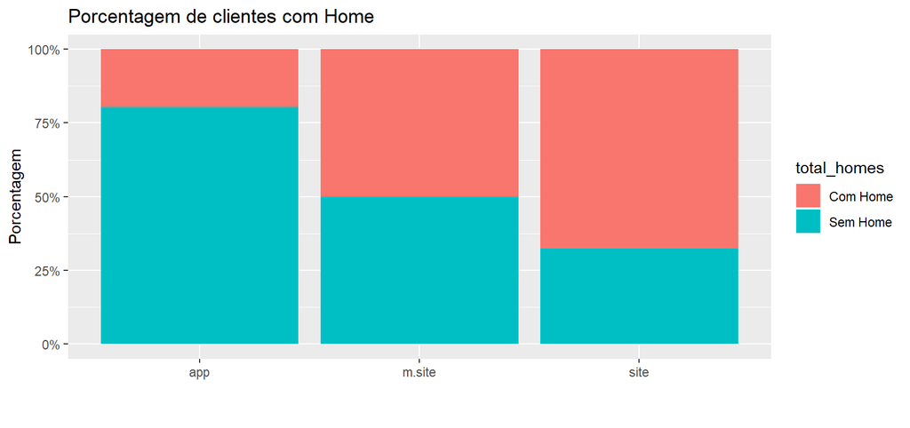

```r
base %>%
  mutate(total_homes = ifelse(total_homes > 0,'Com Home','Sem Home')) %>%
  select(pk_customer,datasource, total_homes) %>%
  unique() %>%
  ggplot() +
  geom_bar(aes(x=datasource, fill=total_homes), position = 'fill')+
  scale_y_continuous(labels = scales::percent_format(), breaks = seq(0,1, by = 0.25))+
   labs(title = "Porcentagem de clientes com Home",
        x = "",
        y = "Porcentagem",
        caption = "",
        colour = ""
   )
```

Aplicativo está com uma taxa de home muito baixa, provavelmente perdemos o tracking de clientes que acessam a home via aplicativo.

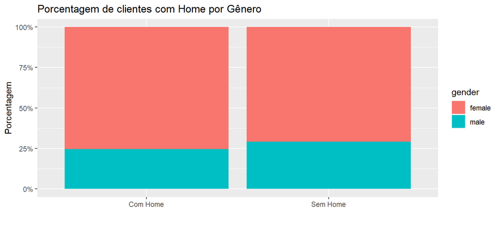

```r
base %>%
  filter(gender != '',
         #datasource == 'site'
         ) %>%
  mutate(total_homes = ifelse(total_homes > 0,'Com Home','Sem Home')) %>%
  select(pk_customer,total_homes,gender) %>%
  unique() %>%
  ggplot() +
  geom_bar(aes(x=as.factor(total_homes), fill = gender), position = 'fill')+
  scale_y_continuous(labels = scales::percent_format(), breaks = seq(0,1, by = 0.25))+
   labs(title = "Porcentagem de clientes com Home por Gênero",
        x = "",
        y = "Porcentagem",
        caption = "",
        colour = ""
       )
```

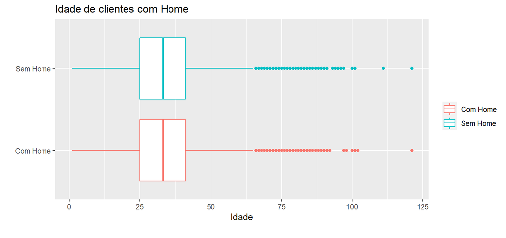

```r
base %>%
  filter(#datasource == 'site'
         ) %>%
  mutate(total_homes = ifelse(total_homes > 0,'Com Home','Sem Home')) %>%
  select(pk_customer,total_homes,age) %>%
  unique() %>%
  ggplot() +
  geom_boxplot(aes(y=as.factor(total_homes), x = age, color = as.factor(total_homes)))+
  labs(title = "Idade de clientes com Home",
        x = "Idade",
        y = "",
        caption = "",
        colour = ""
       )
```

```r
base %>%
  group_by(datasource) %>%
  filter(!is.na(visita_primeira_home),
         #datasource == 'site'
         ) %>%
  summarise(mediana_primeira_visita = median(visita_primeira_home))%>%
  knitr::kable() %>%
  kable_styling(full_width = F)
```

| datasource | mediana_primeira_visita |
| --- | --- |
| app | 1 |
| m.site | 5 |
| site | 4 |

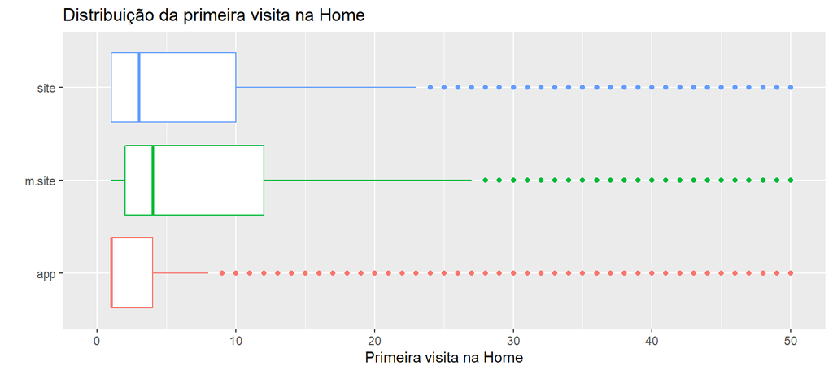

```r
base %>%
  filter(!is.na(visita_primeira_home),
         #datasource == 'site'
         ) %>%
  ggplot() +
  geom_boxplot(aes(x=visita_primeira_home, y=datasource, color = datasource), show.legend = F) +
  xlim(0,50)+
  labs(title = "Distribuição da primeira visita na Home",
        x = "Primeira visita na Home",
        y = "",
        caption = "",
        colour = ""
       )
```

## Analise

```r
aux <- base %>%
  #filter(datasource == 'site') %>%
  mutate(flag_home = ifelse(total_homes > 0,'Com Home','Sem Home'),
         pedidos = ifelse(pedidos > 0, 1, 0)) %>%
  select(pk_customer,datasource, flag_home, pedidos) %>%
  unique() %>%
  group_by(flag_home,datasource) %>%
  summarise(clientes = n(),
            clientes_pedido = sum(pedidos)) %>%
  mutate(porcentagem = round(clientes/sum(clientes)*100,2),
         porcentagem_pedidos = round(clientes_pedido/clientes*100,2)
         )

aux <- aux %>%
  ungroup() %>%
  filter(flag_home == 'Com Home') %>%
  select(datasource, clientes, clientes_pedido, porcentagem,porcentagem_pedidos) %>%
  inner_join(aux %>%
               ungroup() %>%
               filter(flag_home != 'Com Home') %>%
               select(datasource,porcentagem_pedidos) %>%
               rename(porcentagem_pedidos_semHome = porcentagem_pedidos),
             by = 'datasource') %>%
  mutate(incremento_pedidos_abs = round(porcentagem_pedidos-porcentagem_pedidos_semHome,2)) %>%
  select(datasource,clientes,porcentagem,clientes_pedido,porcentagem_pedidos,incremento_pedidos_abs)

aux %>%
  mutate(porcentagem = paste0(porcentagem, '%'),
         porcentagem_clientes_com_pedido = paste0(porcentagem_pedidos, '%'),
         incremento_pedidos_abs = paste0(incremento_pedidos_abs, '%')
         ) %>%
  rename(clientes_com_home = clientes) %>%
  select(datasource,clientes_com_home, porcentagem, porcentagem_clientes_com_pedido,incremento_pedidos_abs) %>%
  knitr::kable() %>%
  kable_styling()
```

| datasource | clientes_com_home | porcentagem | porcentagem_clientes_com_pedido | incremento_pedidos_abs |
| --- | --- | --- | --- | --- |
| app | 29730 | 18.57% | 81.56% | 48.14% |
| m.site | 73543 | 45.94% | 81.27% | 11.6% |
| site | 56826 | 35.49% | 77.13% | 5.12% |

### Período de acesso a home

##### Tabela app

```r
base %>%
  mutate(flag_antes_compra = ifelse(is.na(dia_primeira_home), 'Sem Home',
                                    ifelse(dia_primeira_home <= date_of_first_order_paid | (is.na(date_of_first_order_paid) & total_homes > 0),'Home antes da primeira compra','Home depois da compra')),
         flag_antes_compra = ifelse(is.na(flag_antes_compra), 'Sem Home', flag_antes_compra)
         ) %>%
  group_by(flag_antes_compra,datasource) %>%
  summarise(contagem = n()) %>%
  mutate(porcentagem = contagem/sum(contagem),
         porcentagem = paste(round(porcentagem*100,1),'%',sep = '')) %>%
  inner_join(
    base %>%
      mutate(flag_antes_compra = ifelse(is.na(dia_primeira_home), 'Sem Home',
                                        ifelse(dia_primeira_home <= date_of_first_order_paid | (is.na(date_of_first_order_paid) & total_homes > 0),'Home antes da primeira compra','Home depois da compra')),
             flag_antes_compra = ifelse(is.na(flag_antes_compra), 'Sem Home', flag_antes_compra)
             ) %>%
      group_by(flag_antes_compra,datasource) %>%
      summarise(mediana_total_visitas = median(total_visitas)),
    by = c('flag_antes_compra'= 'flag_antes_compra',
           'datasource'='datasource')
    )%>%
  filter(datasource == 'app') %>%
  knitr::kable() %>%
  kable_styling()
```

| flag_antes_compra | datasource | contagem | porcentagem | mediana_total_visitas |
| --- | --- | --- | --- | --- |
| Home antes da primeira compra | app | 33056 | 22.8% | 28 |
| Home depois da compra | app | 8336 | 11.4% | 43 |
| Sem Home | app | 162801 | 49.9% | 13 |

##### Tabela Desk

```r
base %>%
  mutate(flag_antes_compra = ifelse(is.na(dia_primeira_home), 'Sem Home',
                                    ifelse(dia_primeira_home <= date_of_first_order_paid | (is.na(date_of_first_order_paid) & total_homes > 0),'Home antes da primeira compra','Home depois da compra')),
         flag_antes_compra = ifelse(is.na(flag_antes_compra), 'Sem Home', flag_antes_compra)
         ) %>%
  group_by(flag_antes_compra,datasource) %>%
  summarise(contagem = n()) %>%
  mutate(porcentagem = contagem/sum(contagem),
         porcentagem = paste(round(porcentagem*100,1),'%',sep = '')) %>%
  inner_join(
    base %>%
      mutate(flag_antes_compra = ifelse(is.na(dia_primeira_home), 'Sem Home',
                                        ifelse(dia_primeira_home <= date_of_first_order_paid | (is.na(date_of_first_order_paid) & total_homes > 0),'Home antes da primeira compra','Home depois da compra')),
             flag_antes_compra = ifelse(is.na(flag_antes_compra), 'Sem Home', flag_antes_compra)
             ) %>%
      group_by(flag_antes_compra,datasource) %>%
      summarise(mediana_total_visitas = median(total_visitas)),
    by = c('flag_antes_compra'= 'flag_antes_compra',
           'datasource'='datasource')
    )%>%
  filter(datasource == 'site') %>%
  knitr::kable() %>%
  kable_styling()
```

| flag_antes_compra | datasource | contagem | porcentagem | mediana_total_visitas |
| --- | --- | --- | --- | --- |
| Home antes da primeira compra | site | 52423 | 36.1% | 9 |
| Home depois da compra | site | 27439 | 37.4% | 22 |
| Sem Home | site | 44378 | 13.6% | 5 |

##### Tabela M.Site

```r
base %>%
  mutate(flag_antes_compra = ifelse(is.na(dia_primeira_home), 'Sem Home',
                                    ifelse(dia_primeira_home <= date_of_first_order_paid | (is.na(date_of_first_order_paid) & total_homes > 0),'Home antes da primeira compra','Home depois da compra')),
         flag_antes_compra = ifelse(is.na(flag_antes_compra), 'Sem Home', flag_antes_compra)
         ) %>%
  group_by(flag_antes_compra,datasource) %>%
  summarise(contagem = n()) %>%
  mutate(porcentagem = contagem/sum(contagem),
         porcentagem = paste(round(porcentagem*100,1),'%',sep = '')) %>%
  inner_join(
    base %>%
      mutate(flag_antes_compra = ifelse(is.na(dia_primeira_home), 'Sem Home',
                                        ifelse(dia_primeira_home <= date_of_first_order_paid | (is.na(date_of_first_order_paid) & total_homes > 0),'Home antes da primeira compra','Home depois da compra')),
             flag_antes_compra = ifelse(is.na(flag_antes_compra), 'Sem Home', flag_antes_compra)
             ) %>%
      group_by(flag_antes_compra,datasource) %>%
      summarise(mediana_total_visitas = median(total_visitas)),
    by = c('flag_antes_compra'= 'flag_antes_compra',
           'datasource'='datasource')
    )%>%
  filter(datasource == 'm.site') %>%
  knitr::kable() %>%
  kable_styling()
```

| flag_antes_compra | datasource | contagem | porcentagem | mediana_total_visitas |
| --- | --- | --- | --- | --- |
| Home antes da primeira compra | m.site | 59670 | 41.1% | 9 |
| Home depois da compra | m.site | 37633 | 51.3% | 22 |
| Sem Home | m.site | 119223 | 36.5% | 10 |

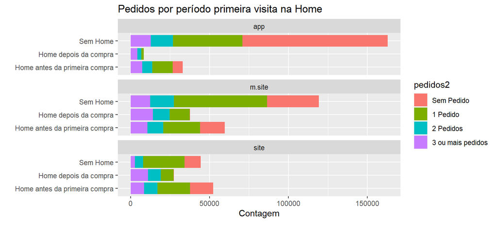

```r
base %>%
  #filter(datasource == 'site') %>%
  mutate(flag_antes_compra = ifelse(is.na(dia_primeira_home), 'Sem Home',
                                    ifelse(dia_primeira_home <= date_of_first_order_paid | (is.na(date_of_first_order_paid) & total_homes > 0),'Home antes da primeira compra','Home depois da compra')),
         flag_antes_compra = ifelse(is.na(flag_antes_compra), 'Sem Home', flag_antes_compra)
         ) %>%
  ggplot() +
  geom_bar(aes(y=flag_antes_compra, fill = pedidos2))+
  #scale_y_continuous(labels = scales::percent_format(), breaks = seq(0,1, by = 0.25))+
  labs(title = "Pedidos por período primeira visita na Home",
        x = "Contagem",
        y = "",
        caption = "",
        colour = ""
       ) +
  facet_wrap(.~datasource, nrow = 3)
```

```r
base2 <- base %>%
  #filter(datasource == 'site') %>%
  mutate(flag_antes_compra = ifelse(is.na(dia_primeira_home), 'Sem Home',
                                    ifelse(dia_primeira_home <= date_of_first_order_paid | (is.na(date_of_first_order_paid) & total_homes > 0),'Home antes da primeira compra','Home depois da compra')),
         flag_antes_compra = ifelse(is.na(flag_antes_compra), 'Sem Home', flag_antes_compra)
         )

x <- base2 %>%
  group_by(total_visitas, flag_antes_compra) %>%
  summarise(contagem = n())

x <- x %>%
  filter(flag_antes_compra == 'Home antes da primeira compra' ) %>%
  select(contagem) %>%
  rename(uma_home = contagem) %>%
  inner_join(
    x %>%
      filter(flag_antes_compra == 'Home depois da compra') %>%
      select(contagem) %>%
      rename(duas_home = contagem),
    by = 'total_visitas'
  ) %>%
  inner_join(
    x %>%
      filter(flag_antes_compra == 'Sem Home') %>%
      select(contagem) %>%
      rename(tres_home = contagem),
    by = 'total_visitas'
  ) %>%
  mutate(menor = pmin(uma_home,duas_home, tres_home))

base2 <- base2 %>%
  inner_join(x %>%
               select(total_visitas, menor),
             by = 'total_visitas') %>%
  group_by(flag_antes_compra, total_visitas) %>%
  mutate(id = row_number()) %>%
  filter(id <= menor)
```

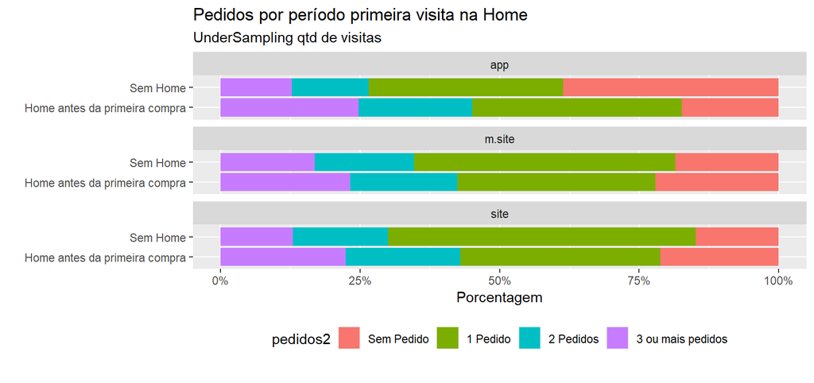

```r
base2 %>%
  filter(flag_antes_compra != 'Home depois da compra') %>%
  ggplot() +
  geom_bar(aes(y=flag_antes_compra, fill = pedidos2), position = 'fill')+
  scale_x_continuous(labels = scales::percent_format(), breaks = seq(0,1, by = 0.25))+
  labs(title = "Pedidos por período primeira visita na Home",
       subtitle = "UnderSampling qtd de visitas",
        x = "Porcentagem",
        y = "",
        caption = "",
        colour = ""
       )+
  theme() +
  theme(legend.position="bottom") +
  facet_wrap(.~datasource, nrow = 3)
```

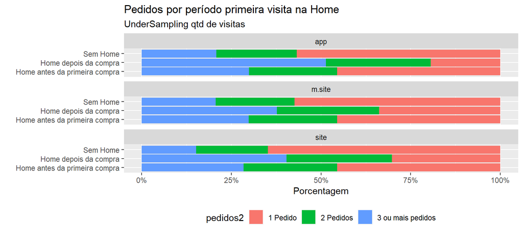

```r
base2 %>%
  filter(pedidos >= 1,
         #datasource == 'site'
         ) %>%
  ggplot() +
  geom_bar(aes(y=flag_antes_compra, fill = pedidos2), position = 'fill')+
  scale_x_continuous(labels = scales::percent_format(), breaks = seq(0,1, by = 0.25))+
  labs(title = "Pedidos por período primeira visita na Home",
       subtitle = "UnderSampling qtd de visitas",
        x = "Porcentagem",
        y = "",
        caption = "",
        colour = ""
       )+
  theme(legend.position="bottom") +
  #theme(axis.text.x = element_text(angle = 10, hjust = 1)) +
  facet_wrap(.~datasource, nrow = 3)
```

#### Perfil dos clientes

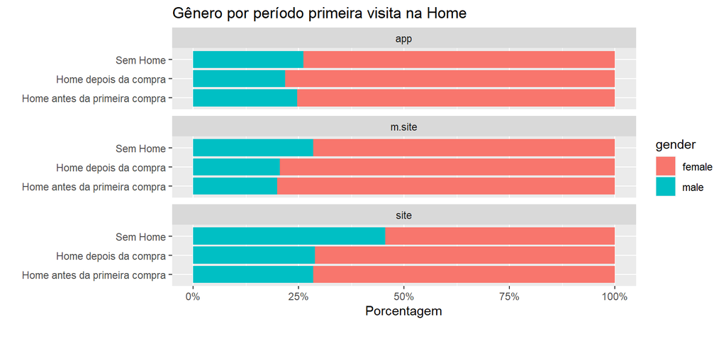

```r
base %>%
  filter(gender != '',
         #datasource == 'site'
         ) %>%
  group_by(pk_customer,gender, date_of_first_order_paid,datasource) %>%
  summarise(dia_primeira_home = min(dia_primeira_home),
            total_homes = sum(total_homes)) %>%
  mutate(flag_antes_compra = ifelse(is.na(dia_primeira_home), 'Sem Home',
                                        ifelse(dia_primeira_home <= date_of_first_order_paid |
                                                 (is.na(date_of_first_order_paid) & total_homes > 0),
                                               'Home antes da primeira compra','Home depois da compra')),
             flag_antes_compra = ifelse(is.na(flag_antes_compra), 'Sem Home', flag_antes_compra)
             ) %>%
  ggplot() +
  geom_bar(aes(y=flag_antes_compra, fill = gender), position = 'fill')+
  scale_x_continuous(labels = scales::percent_format(), breaks = seq(0,1, by = 0.25))+
  labs(title = "Gênero por período primeira visita na Home",
       #subtitle = "UnderSampling qtd de visitas",
        x = "Porcentagem",
        y = "",
        caption = "",
        colour = ""
       ) +
  facet_wrap(.~datasource, nrow = 3)
```

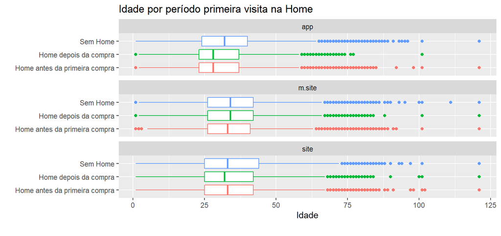

```r
base %>%
  #filter(datasource == 'site') %>%
  group_by(pk_customer,age, date_of_first_order_paid,datasource) %>%
  summarise(dia_primeira_home = min(dia_primeira_home),
            total_homes = sum(total_homes)) %>%
  mutate(flag_antes_compra = ifelse(is.na(dia_primeira_home), 'Sem Home',
                                        ifelse(dia_primeira_home <= date_of_first_order_paid | (is.na(date_of_first_order_paid) & total_homes > 0),'Home antes da primeira compra','Home depois da compra')),
             flag_antes_compra = ifelse(is.na(flag_antes_compra), 'Sem Home', flag_antes_compra)
             ) %>%
  ggplot() +
  geom_boxplot(aes(y=flag_antes_compra, x = age, color = flag_antes_compra), show.legend = F)+
  labs(title = "Idade por período primeira visita na Home",
       #subtitle = "UnderSampling qtd de visitas",
        x = "Idade",
        y = "",
        caption = "",
        colour = ""
       ) +
  facet_wrap(.~datasource, nrow=3)
```

### Diferentes homes

```r
base2 <- base %>%
  #filter(datasource == 'site') %>%
  mutate(total_homes = as.factor(total_homes))

x <- base2 %>%
  group_by(total_visitas, diferentes_homes) %>%
  summarise(contagem = n())

x <- x %>%
  filter(diferentes_homes == 1) %>%
  select(contagem) %>%
  rename(uma_home = contagem) %>%
  inner_join(
    x %>%
      filter(diferentes_homes == 2) %>%
      select(contagem) %>%
      rename(duas_home = contagem),
    by = 'total_visitas'
  ) %>%
  inner_join(
    x %>%
      filter(diferentes_homes == 3) %>%
      select(contagem) %>%
      rename(tres_home = contagem),
    by = 'total_visitas'
  ) %>%
  inner_join(
    x %>%
      filter(diferentes_homes == 4) %>%
      select(contagem) %>%
      rename(quatro_home = contagem),
    by = 'total_visitas'
  ) %>%
  inner_join(
    x %>%
      filter(diferentes_homes == 0) %>%
      select(contagem) %>%
      rename(cinco_home = contagem),
    by = 'total_visitas'
  ) %>%
  mutate(menor = pmin(uma_home,duas_home, tres_home, quatro_home,cinco_home))

base2 <- base2 %>%
  inner_join(x %>%
               select(total_visitas, menor),
             by = 'total_visitas') %>%
  group_by(diferentes_homes, total_visitas) %>%
  mutate(id = row_number()) %>%
  filter(id <= menor)
```

##### Tabela app

```r
base %>%
  #filter(datasource == 'site') %>%
  group_by(diferentes_homes,datasource) %>%
  summarise(contagem = n()) %>%
  mutate(porcentagem = contagem/sum(contagem),
         porcentagem = paste(round(porcentagem*100,1),'%',sep = '')) %>%
  inner_join(
    base %>%
      #filter(datasource == 'site') %>%
      group_by(diferentes_homes,datasource) %>%
      summarise(mediana_total_visitas = median(total_visitas)),
    by = c('diferentes_homes' = 'diferentes_homes',
           'datasource' = 'datasource')
    )%>%
  filter(datasource == 'app') %>%
  knitr::kable() %>%
  kable_styling()
```

| diferentes_homes | datasource | contagem | porcentagem | mediana_total_visitas |
| --- | --- | --- | --- | --- |
| 0 | app | 162837 | 49.8% | 13 |
| 1 | app | 19984 | 14.8% | 24 |
| 2 | app | 11662 | 21.5% | 31 |
| 3 | app | 6354 | 30.4% | 42 |
| 4 | app | 3356 | 42.9% | 62 |

##### Tabela Desk

```r
base %>%
  #filter(datasource == 'site') %>%
  group_by(diferentes_homes,datasource) %>%
  summarise(contagem = n()) %>%
  mutate(porcentagem = contagem/sum(contagem),
         porcentagem = paste(round(porcentagem*100,1),'%',sep = '')) %>%
  inner_join(
    base %>%
      #filter(datasource == 'site') %>%
      group_by(diferentes_homes,datasource) %>%
      summarise(mediana_total_visitas = median(total_visitas)),
    by = c('diferentes_homes' = 'diferentes_homes',
           'datasource' = 'datasource')
    )%>%
  filter(datasource == 'site') %>%
  knitr::kable() %>%
  kable_styling()
```

| diferentes_homes | datasource | contagem | porcentagem | mediana_total_visitas |
| --- | --- | --- | --- | --- |
| 0 | site | 44527 | 13.6% | 5 |
| 1 | site | 50324 | 37.2% | 9 |
| 2 | site | 20202 | 37.3% | 19 |
| 3 | site | 7033 | 33.7% | 32 |
| 4 | site | 2154 | 27.5% | 50 |

##### Tabela M.Site

```r
base %>%
  #filter(datasource == 'site') %>%
  group_by(diferentes_homes,datasource) %>%
  summarise(contagem = n()) %>%
  mutate(porcentagem = contagem/sum(contagem),
         porcentagem = paste(round(porcentagem*100,1),'%',sep = '')) %>%
  inner_join(
    base %>%
      #filter(datasource == 'site') %>%
      group_by(diferentes_homes,datasource) %>%
      summarise(mediana_total_visitas = median(total_visitas)),
    by = c('diferentes_homes' = 'diferentes_homes',
           'datasource' = 'datasource')
    )%>%
  filter(datasource == 'm.site') %>%
  knitr::kable() %>%
  kable_styling()
```

| diferentes_homes | datasource | contagem | porcentagem | mediana_total_visitas |
| --- | --- | --- | --- | --- |
| 0 | m.site | 119317 | 36.5% | 10 |
| 1 | m.site | 65028 | 48% | 10 |
| 2 | m.site | 22358 | 41.2% | 22 |
| 3 | m.site | 7507 | 35.9% | 33 |
| 4 | m.site | 2316 | 29.6% | 48 |

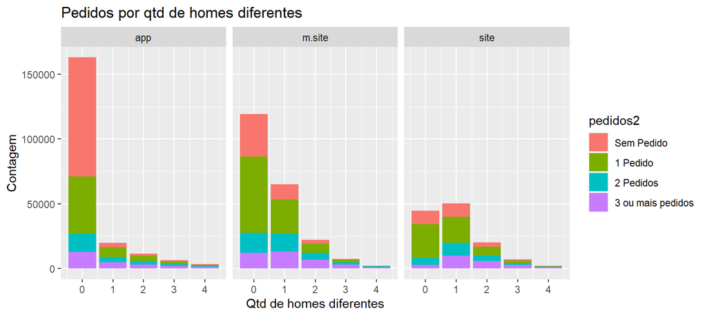

```r
base %>%
  #filter(datasource == 'site') %>%
  group_by(diferentes_homes,pedidos2,datasource) %>%
  summarise(contagem = n()) %>%
  ggplot() +
  geom_col(aes(x=diferentes_homes, y=contagem, fill=pedidos2)) +
  labs(title = "Pedidos por qtd de homes diferentes",
       #subtitle = "UnderSampling qtd de visitas",
        x = "Qtd de homes diferentes",
        y = "Contagem",
        caption = "",
        colour = ""
       ) +
  facet_wrap(.~datasource)
```

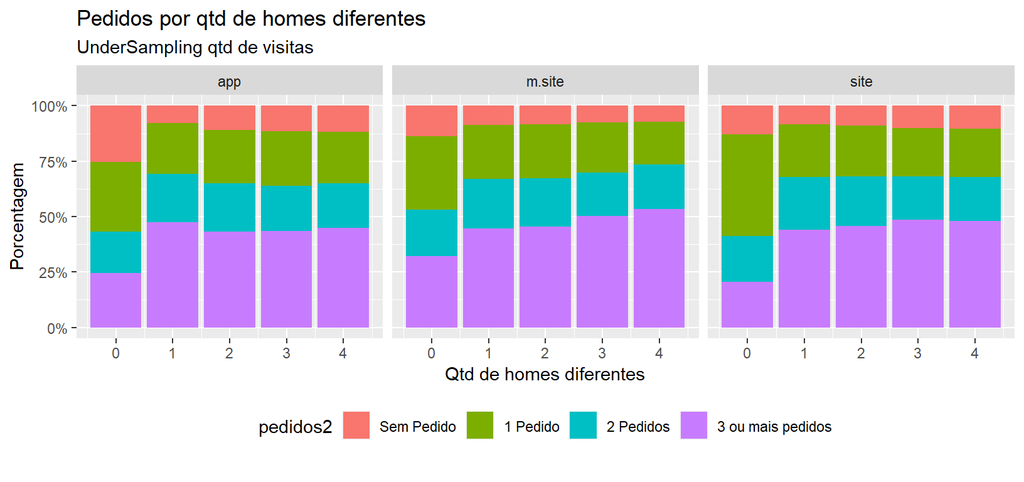

```r
 base2 %>%
  group_by(diferentes_homes,pedidos2,datasource) %>%
  summarise(contagem = n()) %>%
  ggplot() +
  geom_col(aes(x=diferentes_homes, y=contagem, fill=pedidos2), position = 'fill')+
  scale_y_continuous(labels = scales::percent_format(), breaks = seq(0,1, by = 0.25))+
  labs(title = "Pedidos por qtd de homes diferentes",
       subtitle = "UnderSampling qtd de visitas",
        x = "Qtd de homes diferentes",
        y = "Porcentagem",
        caption = "",
        colour = ""
       )+
  theme(legend.position="bottom")+
  facet_wrap(.~datasource)
```

#### Perfil dos clientes

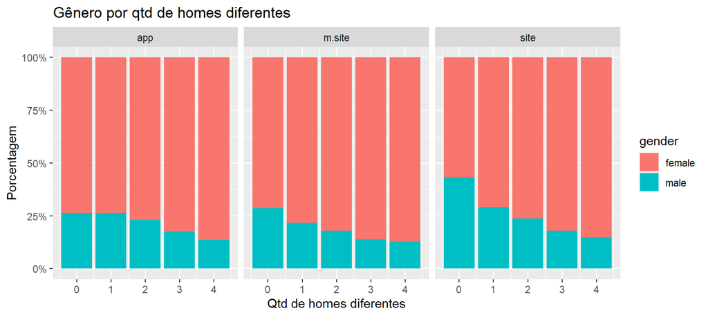

```r
base %>%
  #filter(datasource == 'site') %>%
  filter(gender != '') %>%
  group_by(diferentes_homes,gender,datasource) %>%
  summarise(contagem = n()) %>%
  ggplot() +
  geom_col(aes(x=diferentes_homes, y=contagem, fill=gender), position = 'fill')+
  scale_y_continuous(labels = scales::percent_format(), breaks = seq(0,1, by = 0.25))+
  labs(title = "Gênero por qtd de homes diferentes",
       #subtitle = "UnderSampling qtd de visitas",
        x = "Qtd de homes diferentes",
        y = "Porcentagem",
        caption = "",
        colour = ""
       )+
  facet_wrap(.~datasource)
```

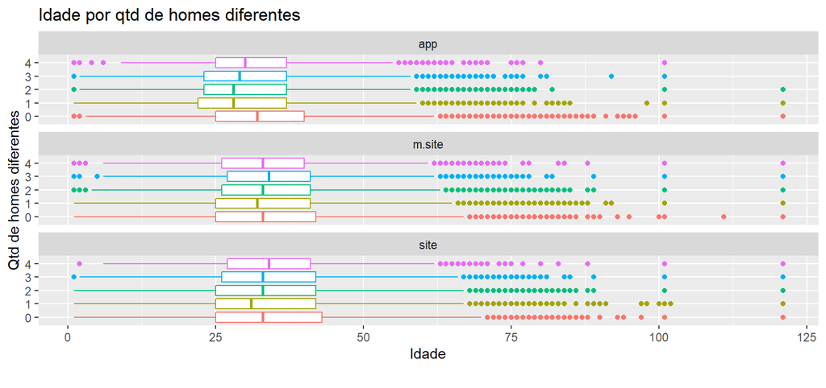

```r
base %>%
  #filter(datasource == 'site') %>%
  ggplot() +
  geom_boxplot(aes(y=as.factor(diferentes_homes), x=age, color=as.factor(diferentes_homes)), show.legend = F)+
  labs(title = "Idade por qtd de homes diferentes",
       #subtitle = "UnderSampling qtd de visitas",
        x = "Idade",
        y = "Qtd de homes diferentes",
        caption = "",
        colour = ""
       )+
  facet_wrap(.~datasource, nrow = 3)
```

### Frequência de acesso a Home

```r
base2 <- base %>%
  #filter(datasource == 'site') %>%
  mutate(porcentagem = qtd_visitas_home/total_visitas,
         porcentagem = ifelse(is.na(porcentagem), 'Sem Home',
                              ifelse(porcentagem == 1,'Todas as vezes',
                              ifelse(porcentagem >= 0.5, 'Entre 50% e 100%',
                                     ifelse(porcentagem >= 0.25, 'Entre 25% e 50%', 'Menos de 25%'))))
  )


x <- base2 %>%
  group_by(total_visitas, porcentagem) %>%
  summarise(contagem = n())

x <- x %>%
  filter(porcentagem == 'Todas as vezes' ) %>%
  select(contagem) %>%
  rename(uma_home = contagem) %>%
  inner_join(
    x %>%
      filter(porcentagem == 'Entre 50% e 100%') %>%
      select(contagem) %>%
      rename(duas_home = contagem),
    by = 'total_visitas'
  ) %>%
  inner_join(
    x %>%
      filter(porcentagem == 'Entre 25% e 50%') %>%
      select(contagem) %>%
      rename(tres_home = contagem),
    by = 'total_visitas'
  ) %>%
  inner_join(
    x %>%
      filter(porcentagem == 'Menos de 25%') %>%
      select(contagem) %>%
      rename(quatro_home = contagem),
    by = 'total_visitas'
  ) %>%
  mutate(menor = pmin(uma_home,duas_home, tres_home,quatro_home))

base2 <- base2 %>%
  inner_join(x %>%
               select(total_visitas, menor),
             by = 'total_visitas') %>%
  group_by(porcentagem, total_visitas) %>%
  mutate(id = row_number()) %>%
  filter(id <= menor)
```

##### Tabela app

```r
aux <- base %>%
  mutate(porcentagem_visitas = qtd_visitas_home/total_visitas,
         porcentagem_visitas = ifelse(is.na(porcentagem_visitas), '1.Sem Home',
                              ifelse(porcentagem_visitas == 1,'5.Todas as vezes',
                              ifelse(porcentagem_visitas >= 0.5, '4.Entre 50% e 100%',
                                     ifelse(porcentagem_visitas >= 0.25, '3.Entre 25% e 50%', '2.Menos de 25%'))))) %>%
  group_by(porcentagem_visitas,datasource) %>%
  summarise(contagem = n()) %>%
  mutate(porcentagem = contagem/sum(contagem),
         porcentagem = paste(round(porcentagem*100,1),'%',sep = '')) %>%
  inner_join(
    base %>%
      #filter(datasource == 'site') %>%
      #filter(qtd_visitas_home >= 1) %>%
      mutate(porcentagem_visitas = qtd_visitas_home/total_visitas,
             porcentagem_visitas = ifelse(is.na(porcentagem_visitas), '1.Sem Home',
                                  ifelse(porcentagem_visitas == 1,'5.Todas as vezes',
                                  ifelse(porcentagem_visitas >= 0.5, '4.Entre 50% e 100%',
                                         ifelse(porcentagem_visitas >= 0.25, '3.Entre 25% e 50%', '2.Menos de 25%'))))) %>%
      group_by(porcentagem_visitas,datasource) %>%
      summarise(mediana_total_visitas = median(total_visitas)),
    by = c('porcentagem_visitas'= 'porcentagem_visitas',
           'datasource'='datasource')
    )

aux %>%
  filter(datasource == 'app') %>%
  knitr::kable() %>%
  kable_styling()
```

| porcentagem_visitas | datasource | contagem | porcentagem | mediana_total_visitas |
| --- | --- | --- | --- | --- |
| 1.Sem Home | app | 162801 | 49.9% | 13 |
| 2.Menos de 25% | app | 3669 | 3.6% | 50 |
| 3.Entre 25% e 50% | app | 6199 | 14.8% | 33 |
| 4.Entre 50% e 100% | app | 27509 | 56.7% | 34 |
| 5.Todas as vezes | app | 4015 | 15.9% | 5 |

##### Tabela Desk

```r
aux %>%
  filter(datasource == 'site') %>%
  knitr::kable() %>%
  kable_styling()
```

| porcentagem_visitas | datasource | contagem | porcentagem | mediana_total_visitas |
| --- | --- | --- | --- | --- |
| 1.Sem Home | site | 44329 | 13.6% | 5 |
| 2.Menos de 25% | site | 42290 | 41.1% | 27 |
| 3.Entre 25% e 50% | site | 16643 | 39.7% | 9 |
| 4.Entre 50% e 100% | site | 10329 | 21.3% | 3 |
| 5.Todas as vezes | site | 10649 | 42.2% | 1 |

##### Tabela M.Site

```r
aux %>%
  filter(datasource == 'm.site') %>%
  knitr::kable() %>%
  kable_styling()
```

| porcentagem_visitas | datasource | contagem | porcentagem | mediana_total_visitas |
| --- | --- | --- | --- | --- |
| 1.Sem Home | m.site | 119207 | 36.5% | 10 |
| 2.Menos de 25% | m.site | 56963 | 55.3% | 25 |
| 3.Entre 25% e 50% | m.site | 19078 | 45.5% | 8 |
| 4.Entre 50% e 100% | m.site | 10682 | 22% | 3 |
| 5.Todas as vezes | m.site | 10596 | 41.9% | 1 |

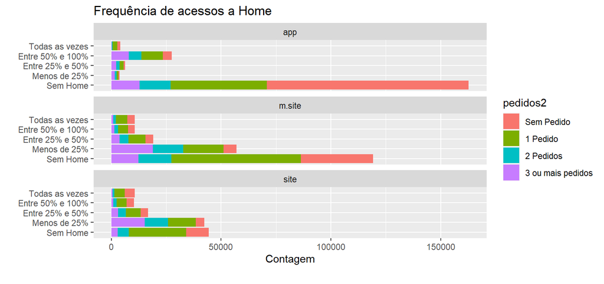

```r
base %>%
  mutate(porcentagem = qtd_visitas_home/total_visitas) %>%
  select(pk_customer, pedidos2, total_visitas, porcentagem,datasource) %>%
  mutate(porcentagem = ifelse(is.na(porcentagem), 'Sem Home',
                              ifelse(porcentagem == 1,'Todas as vezes',
                              ifelse(porcentagem >= 0.5, 'Entre 50% e 100%',
                                     ifelse(porcentagem >= 0.25, 'Entre 25% e 50%', 'Menos de 25%'))))
  ) %>%
  ggplot() +
  geom_bar(aes(y=factor(porcentagem,
                        levels = c('Sem Home', 'Menos de 25%', 'Entre 25% e 50%', 'Entre 50% e 100%', 'Todas as vezes')),
               fill=pedidos2))+
  labs(title = "Frequência de acessos a Home",
       #subtitle = "UnderSampling qtd de visitas",
        x = "Contagem",
        y = "",
        caption = "",
        colour = ""
       )+
  facet_wrap(.~datasource, nrow = 3)
```

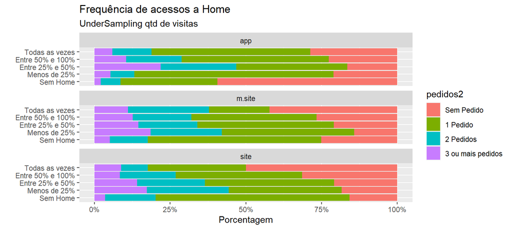

```r
base2 %>%
  #filter(qtd_visitas_home >= 1) %>%
  ggplot() +
  geom_bar(aes(y=factor(porcentagem,
                        levels = c('Sem Home', 'Menos de 25%', 'Entre 25% e 50%', 'Entre 50% e 100%', 'Todas as vezes')),
               fill=pedidos2), position = 'fill')+
  scale_x_continuous(labels = scales::percent_format(), breaks = seq(0,1, by = 0.25))+
  labs(title = "Frequência de acessos a Home",
       subtitle = "UnderSampling qtd de visitas",
        x = "Porcentagem",
        y = "",
        caption = "",
        colour = ""
       )+
  facet_wrap(.~datasource, nrow=3)
```